# Procesamiento de datos masivos con R y RStudio

Yolanda García Ruiz - ygarciar@ucm.es

23/09/2025

# 1 Importar y exportar datos

Para la importación de datos, R proporciona varias funciones y paquetes para leer diferentes formatos de archivo, como CSV, Excel o JSON.

La Cheat Sheet correspondiente a la importación de datos se encuentra en este link.

## 1.1 Ficheros de texto en formato csv

En muchas ocasiones los datos en encuentran almacenados en ficheros de texto y representados en forma de tabla. El formato más popular es el `CSV` , donde los valores de cada una de las filas están separados por el símbolo coma (`,`). En otras ocasiones, los valores de cada fila están separados por otro símbolo, un tabulador o un espacio. Este tipo de ficheros normalmente tienen extensión `.txt`.

Aunque R puede importar datos de archivos CSV con las funciones en R base, aquí vamos a ver cómo se importan este tipo de archivos con las funciones de la biblioteca `readr`, contenida en `tidyverse`.

```r
# carga de la librería
library(readr)
```

La mayoría de las funciones de **`readr`** permiten transformar archivos planos en dataframe*s*.

- `read_csv()` lee archivos delimitados por coma. Existe la función `read.csv` en R base, pero `read_csv()` suele ser significativamente más rápida, especialmente para archivos grandes, gracias a su implementación en C++.
- `read_csv2()` lee archivos separados por punto y coma (`;`) (comunes en países donde el caracter coma (`,`) es utilizado para separar decimales)
- `read_tsv()` lee archivos delimitados por tabulaciones y
- `read_delim()` archivos con cualquier delimitador.

Todas estas funciones admiten varios parámetros que permiten configurar cómo se debe realizar la carga de datos. No es necesario aprenderlos todos, ya que lo más cómodo es usar la interfaz gráfica que nos proporciona RStudio para cargar datos. Sin embargo conviene entender el código R generado para poder utilizarlo en nuestros Scripts de R.

Vamos a cargar un archivo csv desde interfaz gráfica de RStudio. Ir a la pestaña `Environment`, con la opción `Import Dataset -> From Text (readr)`:

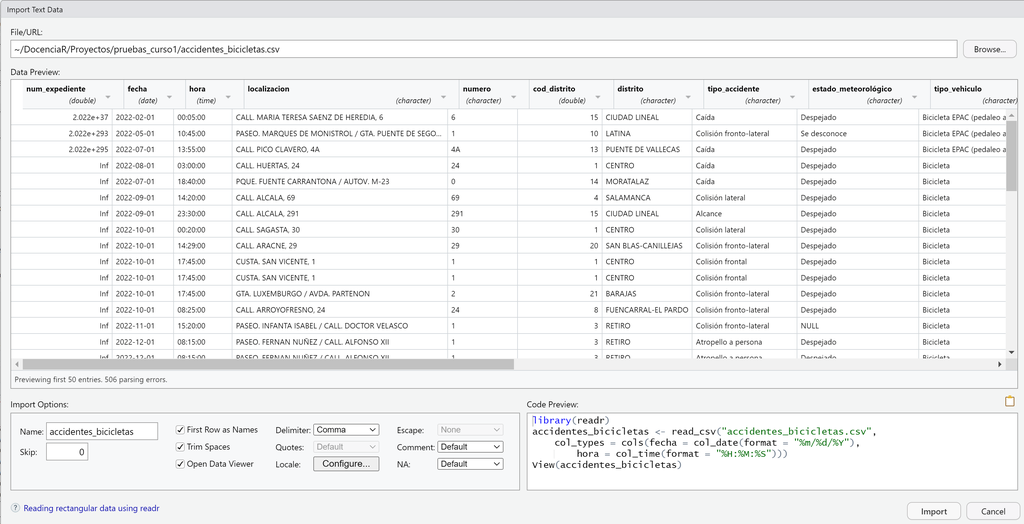

Esta interfaz gráfica facilita el proceso de importación y permite configurar varias opciones para ajustar cómo se leen los datos. Estas opciones son comunes a todas las funciones de carga que hemos visto anteriormente. Entre las opciones tenemos:

1. **File/URL:** archivo de texto que deseas importar desde tu sistema de archivos o especificar una URL desde la que se descargará el archivo.
2. **First row as Names:** `Yes`: Indica que el archivo de texto tiene una fila de encabezado con los nombres de las columnas. `No`: Indica que el archivo de texto no tiene una fila de encabezado y se asignarán nombres de columna predeterminados (X1, X2, …).
3. **Delimiter:** permite indicar el separador de campos. `Comma`: Usado para archivos CSV (valores separados por comas). `Tab`: Usado para valores separados por tabulaciones, `Semicolon`: Usado para archivos donde los valores están separados por punto y coma. También permite indicar otro delimitador distinto de los anteriores.
4. **Quote:** Permite especificar el carácter de comillas que se utiliza para encerrar los valores de texto en el archivo. Las opciones comunes son: `None`: No hay caracteres de comillas. `Double Quote`: Comillas dobles (`"`). `Single Quote`: Comillas simples (`'`).
5. **NA:** Permite especificar qué cadena(s) de texto en el archivo de texto deben ser interpretadas como valores NA (missing values).
6. **Skip:** Permite especificar cuántas líneas iniciales del archivo deben ser omitidas antes de empezar a leer los datos.
7. **Trim Spaces:** `Yes`: Elimina los espacios en blanco al principio y al final de los valores de texto. `No`: Mantiene los espacios en blanco al principio y al final de los valores de texto.

La interfaz muestra una vista previa de los primeros registros del archivo, lo que permite verificar que las opciones de importación se han configurado correctamente.

Con respecto a los tipos de cada una de las columnas, R infiere los tipos de forma automática, pero conviene revisarlos y modificarlos al tipo correcto cuando sea necesario.

Una vez configurada la carga y revisado los tipos de datos, podemos copiar el código que aparece en la parte inferior derecha de la interfaz y pegarlo en nuestro Script:

```r
# lectura de datos en un fichero csv
accidentes <- read_csv("../data/accidentes_bicicletas.csv",
        col_types = cols(fecha = col_date(format = "%d/%m/%Y"),
                         hora  = col_time(format = "%H:%M:%S")))
accidentes
```

```
## # A tibble: 878 × 19
##    num_expediente fecha      hora   localizacion    numero cod_distrito distrito
##             <dbl> <date>     <time> <chr>           <chr>         <dbl> <chr>
##  1       2.02e 37 2022-01-02 00:05  CALL. MARIA TE… 6                15 CIUDAD …
##  2       2.02e293 2022-01-05 10:45  PASEO. MARQUES… 1                10 LATINA
##  3       2.02e295 2022-01-07 13:55  CALL. PICO CLA… 4A               13 PUENTE …
##  4     Inf        2022-01-08 03:00  CALL. HUERTAS,… 24                1 CENTRO
##  5     Inf        2022-01-07 18:40  PQUE. FUENTE C… 0                14 MORATAL…
##  6     Inf        2022-01-09 14:20  CALL. ALCALA, … 69                4 SALAMAN…
##  7     Inf        2022-01-09 23:30  CALL. ALCALA, … 291              15 CIUDAD …
##  8     Inf        2022-01-10 00:20  CALL. SAGASTA,… 30                1 CENTRO
##  9     Inf        2022-01-10 14:29  CALL. ARACNE, … 29               20 SAN BLA…
## 10     Inf        2022-01-10 17:45  CUSTA. SAN VIC… 1                 1 CENTRO
## # ℹ 868 more rows
## # ℹ 12 more variables: tipo_accidente <chr>, estado_meteorológico <chr>,
## #   tipo_vehiculo <chr>, tipo_persona <chr>, rango_edad <chr>, sexo <chr>,
## #   cod_lesividad <chr>, lesividad <chr>, coordenada_x_utm <chr>,
## #   coordenada_y_utm <chr>, positiva_alcohol <chr>, positiva_droga <chr>
```

En nuestro caso, la instrucción de carga incluye la indicación de que las columnas fecha y hora han de cargarse como datos de tipo fecha y hora, cada uno con su formato.

### 1.1.1 Algunos ejemplos

**Ejemplo 1. Información sin cabeceras**

```
Big brown bat,0.023,0.3
Mouse,0.023,0.4
Ground squirrel,0.101,4
Tree shrew,0.104,2.5
Golden hamster,0.12,1
Mole,0.122,3
Galago,0.2,5 Rat,0.28,1.9
```

En este caso, en la interfaz desmarcaremos la opción de **First row as Names**, y el código R generado es:

```r
# lectura de datos en un fichero csv sin cabeceras
animals2 <- read_csv("../data/animals2.csv",
                      col_names = FALSE)
animals2
```

```
## # A tibble: 8 × 3
##   X1                 X2    X3
##   <chr>           <dbl> <dbl>
## 1 Big brown bat   0.023   0.3
## 2 Mouse           0.023   0.4
## 3 Ground squirrel 0.101   4
## 4 Tree shrew      0.104   2.5
## 5 Golden hamster  0.12    1
## 6 Mole            0.122   3
## 7 Galago          0.2     5
## 8 Rat             0.28    1.9
```

Alternativamente podemos utilizar `col_names` con el vector de nombres que será utilizado como nombres de columna:

```r
# lectura de datos en un fichero csv sin cabeceras
# incluimos los nombres de las columnas a mano
animals2 <- read_csv("../data/animals2.csv",
                      col_names = c('Nombre', 'Peso Cerebro', 'Peso cuerpo'))
animals2
```

```
## # A tibble: 8 × 3
##   Nombre          `Peso Cerebro` `Peso cuerpo`
##   <chr>                    <dbl>         <dbl>
## 1 Big brown bat            0.023           0.3
## 2 Mouse                    0.023           0.4
## 3 Ground squirrel          0.101           4
## 4 Tree shrew               0.104           2.5
## 5 Golden hamster           0.12            1
## 6 Mole                     0.122           3
## 7 Galago                   0.2             5
## 8 Rat                      0.28            1.9
```

O asignar nombres manualmente después de haber realizado la carga

```r
# podemos actualizar los nombres de columnas
# una vez cargado el fichero
colnames(animals2) <- c('Nombre', 'Peso_Cerebro', 'Peso_Cuerpo')
animals2
```

```
## # A tibble: 8 × 3
##   Nombre          Peso_Cerebro Peso_Cuerpo
##   <chr>                  <dbl>       <dbl>
## 1 Big brown bat          0.023         0.3
## 2 Mouse                  0.023         0.4
## 3 Ground squirrel        0.101         4
## 4 Tree shrew             0.104         2.5
## 5 Golden hamster         0.12          1
## 6 Mole                   0.122         3
## 7 Galago                 0.2           5
## 8 Rat                    0.28          1.9
```

**Ejemplo 2: Metadatos al comienzo del fichero**

En algunas ocasiones las primeras líneas del fichero no se corresponden con datos propiamente dichos, si no que simplemente aportan una descripción de los datos que contiene (ver peliculas.csv).

```
Cine de los 90
*********************************
Estreno: Fecha de estreno
Nombre: Título de la película
Cat: Género de la película
*********************************
Estreno,Nombre,Cat
1982,E.T. the ExtraTerrestrial,Fantasy
1982,Poltergeist,Horror
1992,Alien,Action
1992,The Crying Game,War
1995,Toy Story,Animation
1995,GoldenEye,Action
1995,Four Rooms,Thriller
```

En este caso, el valor de la opción **skip** en la interfaz es 6, puesto que las primeras 6 líneas son comentarios. Además, hemos forzado a que el tipo de datos de la columna Estreno sea de tipo `Integer` . El código R generado es:

```r
# saltando filas
peliculas <- read_csv("../data/peliculas.csv",
                   col_types = cols(Estreno = col_integer()),
                   skip = 6)
peliculas
```

```
## # A tibble: 7 × 3
##   Estreno Nombre                    Cat
##     <int> <chr>                     <chr>
## 1    1982 E.T. the ExtraTerrestrial Fantasy
## 2    1982 Poltergeist               Horror
## 3    1992 Alien                     Action
## 4    1992 The Crying Game           War
## 5    1995 Toy Story                 Animation
## 6    1995 GoldenEye                 Action
## 7    1995 Four Rooms                Thriller
```

**Ejemplo 3: Lectura de un fragmento del fichero**

Cuando los ficheros de datos que queremos procesar son muy grandes, podemos realizar una lectura por partes mediante el argumento `n_max`. El argumento `n_max` permite procesar un numero determinado de filas del fichero.

```r
# Lectura de un fragmento del fichero
peliculas <- read_csv("../data/peliculas.csv",
                  col_types = cols(Estreno = col_integer()),
                  n_max = 2,
                  skip = 6)
peliculas
```

```
## # A tibble: 2 × 3
##   Estreno Nombre                    Cat
##     <int> <chr>                     <chr>
## 1    1982 E.T. the ExtraTerrestrial Fantasy
## 2    1982 Poltergeist               Horror
```

Para leer solo un pequeño número de columnas usamos el argumento `col_select`, indicando el nombre o posición de las columnas a importar.

```r
# Lectura de un subconjunto de columnas
accidentes <- read_csv("../data/accidentes_bicicletas.csv",
               col_select = c('distrito', 'numero'),
               n_max = 5)
accidentes
```

```
## # A tibble: 5 × 2
##   distrito           numero
##   <chr>              <chr>
## 1 CIUDAD LINEAL      6
## 2 LATINA             1
## 3 PUENTE DE VALLECAS 4A
## 4 CENTRO             24
## 5 MORATALAZ          0
```

## 1.2 Crear dataframes a partir de una URL

Podemos crear dataframes a partir de datos externos a nuestro PC, desde una dirección ftp o desde una URL donde estén disponibles ficheros en formato CSV. Por ejemplo, podemos descargar datos desde el catálogo de datos abiertos de Madrid:

```r
# Lectura de fichero a través de una URL
t <- read_delim("https://datos.madrid.es/egob/catalogo/300110-24-accidentes-bicicleta.csv",
          delim = ";")
head(t)
```

```
## # A tibble: 6 × 19
##   num_expediente fecha      hora   localizacion     numero cod_distrito distrito
##            <dbl> <chr>      <time> <chr>            <chr>         <dbl> <chr>
## 1       2.02e 37 02/01/2022 00:05  CALL. MARIA TER… 6                15 CIUDAD …
## 2       2.02e293 05/01/2022 10:45  PASEO. MARQUES … 1                10 LATINA
## 3       2.02e295 07/01/2022 13:55  CALL. PICO CLAV… 4A               13 PUENTE …
## 4     Inf        08/01/2022 03:00  CALL. HUERTAS, … 24                1 CENTRO
## 5     Inf        07/01/2022 18:40  PQUE. FUENTE CA… 0                14 MORATAL…
## 6     Inf        09/01/2022 14:20  CALL. ALCALA, 69 69                4 SALAMAN…
## # ℹ 12 more variables: tipo_accidente <chr>, estado_meteorológico <chr>,
## #   tipo_vehiculo <chr>, tipo_persona <chr>, rango_edad <chr>, sexo <chr>,
## #   cod_lesividad <chr>, lesividad <chr>, coordenada_x_utm <chr>,
## #   coordenada_y_utm <chr>, positiva_alcohol <chr>, positiva_droga <chr>
```

En este caso, al tratarse de datos cuyo separador de campos es punto y coma (`;`), la función que utilizamos es `read_delim()`.

## 1.3 Archivos Microsoft Excel ( .xls, .xlsx)

Para crear dataframes a partir de este tipo de archivos usamos la función `read_excel()` definida en el paquete `readxl`, contenido en la biblioteca `tidyverse`.

```r
# Carga de la librería
library(readxl)
```

La función `read_excel()` permite crear objetos de tipo dataframe a partir de los datos contenidos en ficheros con extensión `.xls` y `.xlsx`. En ella se pueden utilizar argumentos como:

- `path`: (ruta del archivo a importar)
- `sheet`: (pestaña a importar)
- `range`: (rango de celdas a importar)
- `col_names`: (encabezados de las columnas).
- Otra función que sirve de ayuda es `excel_sheets()`, que consulta el nombre de las pestañas del archivo Excel.
- `n_max`: número de filas a cargar
- `skip`: número de filas a saltar al comienzo

Veamos un ejemplo con el archivo clientes.xlsx

```r
# permite lista el nombre de las horas que hay
# en un libro Excel
excel_sheets("../data/clientes.xlsx")   # 2 hojas dentro del libro
```

```
## [1] "Hoja1" "Hoja2"
```

```r
# lectura de hoja excel y un rango de filas y columnas
df_excel <- read_excel(path="../data/clientes.xlsx",
                       sheet="Hoja2",
                       range="A1:C6")
df_excel
```

```
## # A tibble: 5 × 3
##   CODCLI    EUROS    MAX
##   <chr>     <dbl>  <dbl>
## 1 CLI-0001  89574 100000
## 2 CLI-0019  68752  80000
## 3 CLI-0020  63014  70000
## 4 CLI-0015  10000  40000
## 5 CLI-0047 148471 251484
```

## 1.4 Exportar datos con `write`

Los datos almacenados en dataframes, pueden ser almacenados en archivos de disco. Esta es una operación que se realiza de forma habitual después del procesamiento de datos, limpieza, etc.

- Por ejemplo, para escribir los datos incluidos en un dataframes en un fichero CSV utilizamos la función `write_csv()` . Existen otras funciones de la misma familia `write_*()` incluidas en `readr` que permiten escribir datos en archivos de texto usando otros delimitadores.
- Si queremos que el destino sea un archivo en formato EXCEL, lo mejor es usar la función función `write_xlsx()` incluida en la biblioteca `writexl`.

Los argumentos más importantes son `x` (el data frame a guardar) y `file` (la ubicación donde se guardará el archivo). También se puede configurar cómo se escriben los valores ausentes con `na` .

```r
# tibble
t
```

```
## # A tibble: 878 × 19
##    num_expediente fecha      hora   localizacion    numero cod_distrito distrito
##             <dbl> <chr>      <time> <chr>           <chr>         <dbl> <chr>
##  1       2.02e 37 02/01/2022 00:05  CALL. MARIA TE… 6                15 CIUDAD …
##  2       2.02e293 05/01/2022 10:45  PASEO. MARQUES… 1                10 LATINA
##  3       2.02e295 07/01/2022 13:55  CALL. PICO CLA… 4A               13 PUENTE …
##  4     Inf        08/01/2022 03:00  CALL. HUERTAS,… 24                1 CENTRO
##  5     Inf        07/01/2022 18:40  PQUE. FUENTE C… 0                14 MORATAL…
##  6     Inf        09/01/2022 14:20  CALL. ALCALA, … 69                4 SALAMAN…
##  7     Inf        09/01/2022 23:30  CALL. ALCALA, … 291              15 CIUDAD …
##  8     Inf        10/01/2022 00:20  CALL. SAGASTA,… 30                1 CENTRO
##  9     Inf        10/01/2022 14:29  CALL. ARACNE, … 29               20 SAN BLA…
## 10     Inf        10/01/2022 17:45  CUSTA. SAN VIC… 1                 1 CENTRO
## # ℹ 868 more rows
## # ℹ 12 more variables: tipo_accidente <chr>, estado_meteorológico <chr>,
## #   tipo_vehiculo <chr>, tipo_persona <chr>, rango_edad <chr>, sexo <chr>,
## #   cod_lesividad <chr>, lesividad <chr>, coordenada_x_utm <chr>,
## #   coordenada_y_utm <chr>, positiva_alcohol <chr>, positiva_droga <chr>
```

```r
# Escribimos l datos en el fichero volcado_1.csv
write_csv(x = t, file = 'volcado_1.csv')
```

La función `write_csv2()` se diferencia de `write_csv()` en que el separador de columnas utilizado es un punto y coma (`;`) y el separador de decimales es una coma (`,`) .

En el caso de Excel:

```r
# carga de librería
library(writexl)
```

```r
# Escribimos los datos en el fichero t.xlsx
write_xlsx(x = t, path = 't.xlsx')
```

## 1.5 Otros formatos de archivos

Para trabajar con otros formatos u otras fuentes de datos, existen otras librerías:

- **haven** lee archivos SPSS, Stata y SAS.
- **DBI**, junto con un *backend* de base de datos específico (e.g. **RMySQL**, **RSQLite**, **RPostgreSQL**, etc.) es posible ejecutar consultas SQL contra una base de datos y obtener un dataframe.
- **jsonlite**, para datos en formato JSON

# 2 Referencias

1. Cheat Sheet https://github.com/rstudio/cheatsheets/blob/main/data-import.pdf
2. https://es.r4ds.hadley.nz/11-import.html
3. readr package https://readr.tidyverse.org/
4. readr package https://cran.r-project.org/web/packages/readr/readr.pdf
5. readxl package https://readxl.tidyverse.org/